# Risk Factor Analysis

## Outcome Variable

**Outcome Variable:** ever_stunted

## Predictor Variables

**Intervention Variable:** mage

**Adjustment Set:**

unadjusted

## Stratifying Variables

The analysis was stratified on these variable(s):

- agecat
- studyid
- country

## Data Summary

| agecat | studyid | country | mage | ever_stunted | n_cell | n |
| --- | --- | --- | --- | --- | --- | --- |
| 0-24 months | ki0047075b-MAL-ED | BANGLADESH | [20-30) | 0 | 77 | 265 |
| 0-24 months | ki0047075b-MAL-ED | BANGLADESH | [20-30) | 1 | 105 | 265 |
| 0-24 months | ki0047075b-MAL-ED | BANGLADESH | <20 | 0 | 8 | 265 |
| 0-24 months | ki0047075b-MAL-ED | BANGLADESH | <20 | 1 | 29 | 265 |
| 0-24 months | ki0047075b-MAL-ED | BANGLADESH | >=30 | 0 | 18 | 265 |
| 0-24 months | ki0047075b-MAL-ED | BANGLADESH | >=30 | 1 | 28 | 265 |
| 0-24 months | ki0047075b-MAL-ED | BRAZIL | [20-30) | 0 | 99 | 233 |
| 0-24 months | ki0047075b-MAL-ED | BRAZIL | [20-30) | 1 | 40 | 233 |
| 0-24 months | ki0047075b-MAL-ED | BRAZIL | <20 | 0 | 32 | 233 |
| 0-24 months | ki0047075b-MAL-ED | BRAZIL | <20 | 1 | 11 | 233 |
| 0-24 months | ki0047075b-MAL-ED | BRAZIL | >=30 | 0 | 39 | 233 |
| 0-24 months | ki0047075b-MAL-ED | BRAZIL | >=30 | 1 | 12 | 233 |
| 0-24 months | ki0047075b-MAL-ED | INDIA | [20-30) | 0 | 75 | 249 |
| 0-24 months | ki0047075b-MAL-ED | INDIA | [20-30) | 1 | 119 | 249 |
| 0-24 months | ki0047075b-MAL-ED | INDIA | <20 | 0 | 13 | 249 |
| 0-24 months | ki0047075b-MAL-ED | INDIA | <20 | 1 | 21 | 249 |
| 0-24 months | ki0047075b-MAL-ED | INDIA | >=30 | 0 | 11 | 249 |
| 0-24 months | ki0047075b-MAL-ED | INDIA | >=30 | 1 | 10 | 249 |
| 0-24 months | ki0047075b-MAL-ED | NEPAL | [20-30) | 0 | 126 | 240 |
| 0-24 months | ki0047075b-MAL-ED | NEPAL | [20-30) | 1 | 63 | 240 |
| 0-24 months | ki0047075b-MAL-ED | NEPAL | <20 | 0 | 2 | 240 |
| 0-24 months | ki0047075b-MAL-ED | NEPAL | <20 | 1 | 3 | 240 |
| 0-24 months | ki0047075b-MAL-ED | NEPAL | >=30 | 0 | 28 | 240 |
| 0-24 months | ki0047075b-MAL-ED | NEPAL | >=30 | 1 | 18 | 240 |
| 0-24 months | ki0047075b-MAL-ED | PERU | [20-30) | 0 | 61 | 303 |
| 0-24 months | ki0047075b-MAL-ED | PERU | [20-30) | 1 | 92 | 303 |
| 0-24 months | ki0047075b-MAL-ED | PERU | <20 | 0 | 29 | 303 |
| 0-24 months | ki0047075b-MAL-ED | PERU | <20 | 1 | 54 | 303 |
| 0-24 months | ki0047075b-MAL-ED | PERU | >=30 | 0 | 25 | 303 |
| 0-24 months | ki0047075b-MAL-ED | PERU | >=30 | 1 | 42 | 303 |

[output cut: 450 more lines]

The following strata were considered:

- agecat: 0-24 months, studyid: ki0047075b-MAL-ED, country: BANGLADESH
- agecat: 0-24 months, studyid: ki0047075b-MAL-ED, country: BRAZIL
- agecat: 0-24 months, studyid: ki0047075b-MAL-ED, country: INDIA
- agecat: 0-24 months, studyid: ki0047075b-MAL-ED, country: NEPAL
- agecat: 0-24 months, studyid: ki0047075b-MAL-ED, country: PERU
- agecat: 0-24 months, studyid: ki0047075b-MAL-ED, country: SOUTH AFRICA
- agecat: 0-24 months, studyid: ki0047075b-MAL-ED, country: TANZANIA, UNITED REPUBLIC OF
- agecat: 0-24 months, studyid: ki1000108-CMC-V-BCS-2002, country: INDIA
- agecat: 0-24 months, studyid: ki1000108-IRC, country: INDIA
- agecat: 0-24 months, studyid: ki1000109-EE, country: PAKISTAN
- agecat: 0-24 months, studyid: ki1000304b-SAS-CompFeed, country: INDIA
- agecat: 0-24 months, studyid: ki1000304b-SAS-FoodSuppl, country: INDIA
- agecat: 0-24 months, studyid: ki1017093-NIH-Birth, country: BANGLADESH
- agecat: 0-24 months, studyid: ki1017093b-PROVIDE, country: BANGLADESH
- agecat: 0-24 months, studyid: ki1017093c-NIH-Crypto, country: BANGLADESH
- agecat: 0-24 months, studyid: ki1066203-TanzaniaChild2, country: TANZANIA, UNITED REPUBLIC OF
- agecat: 0-24 months, studyid: ki1101329-Keneba, country: GAMBIA
- agecat: 0-24 months, studyid: ki1112895-Guatemala BSC, country: GUATEMALA
- agecat: 0-24 months, studyid: ki1112895-iLiNS-Zinc, country: BURKINA FASO
- agecat: 0-24 months, studyid: ki1113344-GMS-Nepal, country: NEPAL
- agecat: 0-24 months, studyid: ki1119695-PROBIT, country: BELARUS
- agecat: 0-24 months, studyid: ki1126311-ZVITAMBO, country: ZIMBABWE
- agecat: 0-24 months, studyid: ki1135781-COHORTS, country: GUATEMALA
- agecat: 0-24 months, studyid: ki1135781-COHORTS, country: INDIA
- agecat: 0-24 months, studyid: ki1135781-COHORTS, country: PHILIPPINES
- agecat: 0-24 months, studyid: ki1148112-LCNI-5, country: MALAWI
- agecat: 0-24 months, studyid: kiGH5241-JiVitA-3, country: BANGLADESH
- agecat: 0-6 months, studyid: ki0047075b-MAL-ED, country: BANGLADESH
- agecat: 0-6 months, studyid: ki0047075b-MAL-ED, country: BRAZIL
- agecat: 0-6 months, studyid: ki0047075b-MAL-ED, country: INDIA
- agecat: 0-6 months, studyid: ki0047075b-MAL-ED, country: NEPAL
- agecat: 0-6 months, studyid: ki0047075b-MAL-ED, country: PERU
- agecat: 0-6 months, studyid: ki0047075b-MAL-ED, country: SOUTH AFRICA
- agecat: 0-6 months, studyid: ki0047075b-MAL-ED, country: TANZANIA, UNITED REPUBLIC OF
- agecat: 0-6 months, studyid: ki1000108-CMC-V-BCS-2002, country: INDIA
- agecat: 0-6 months, studyid: ki1000108-IRC, country: INDIA
- agecat: 0-6 months, studyid: ki1000109-EE, country: PAKISTAN
- agecat: 0-6 months, studyid: ki1000304b-SAS-CompFeed, country: INDIA
- agecat: 0-6 months, studyid: ki1000304b-SAS-FoodSuppl, country: INDIA
- agecat: 0-6 months, studyid: ki1017093-NIH-Birth, country: BANGLADESH
- agecat: 0-6 months, studyid: ki1017093b-PROVIDE, country: BANGLADESH
- agecat: 0-6 months, studyid: ki1017093c-NIH-Crypto, country: BANGLADESH
- agecat: 0-6 months, studyid: ki1066203-TanzaniaChild2, country: TANZANIA, UNITED REPUBLIC OF
- agecat: 0-6 months, studyid: ki1101329-Keneba, country: GAMBIA
- agecat: 0-6 months, studyid: ki1112895-Guatemala BSC, country: GUATEMALA
- agecat: 0-6 months, studyid: ki1113344-GMS-Nepal, country: NEPAL
- agecat: 0-6 months, studyid: ki1119695-PROBIT, country: BELARUS
- agecat: 0-6 months, studyid: ki1126311-ZVITAMBO, country: ZIMBABWE
- agecat: 0-6 months, studyid: ki1135781-COHORTS, country: GUATEMALA
- agecat: 0-6 months, studyid: ki1135781-COHORTS, country: INDIA
- agecat: 0-6 months, studyid: ki1135781-COHORTS, country: PHILIPPINES
- agecat: 0-6 months, studyid: ki1148112-LCNI-5, country: MALAWI
- agecat: 0-6 months, studyid: kiGH5241-JiVitA-3, country: BANGLADESH
- agecat: 6-24 months, studyid: ki0047075b-MAL-ED, country: BANGLADESH
- agecat: 6-24 months, studyid: ki0047075b-MAL-ED, country: BRAZIL
- agecat: 6-24 months, studyid: ki0047075b-MAL-ED, country: INDIA
- agecat: 6-24 months, studyid: ki0047075b-MAL-ED, country: NEPAL
- agecat: 6-24 months, studyid: ki0047075b-MAL-ED, country: PERU
- agecat: 6-24 months, studyid: ki0047075b-MAL-ED, country: SOUTH AFRICA
- agecat: 6-24 months, studyid: ki0047075b-MAL-ED, country: TANZANIA, UNITED REPUBLIC OF
- agecat: 6-24 months, studyid: ki1000108-CMC-V-BCS-2002, country: INDIA
- agecat: 6-24 months, studyid: ki1000108-IRC, country: INDIA
- agecat: 6-24 months, studyid: ki1000109-EE, country: PAKISTAN
- agecat: 6-24 months, studyid: ki1000304b-SAS-CompFeed, country: INDIA
- agecat: 6-24 months, studyid: ki1000304b-SAS-FoodSuppl, country: INDIA
- agecat: 6-24 months, studyid: ki1017093-NIH-Birth, country: BANGLADESH
- agecat: 6-24 months, studyid: ki1017093b-PROVIDE, country: BANGLADESH
- agecat: 6-24 months, studyid: ki1017093c-NIH-Crypto, country: BANGLADESH
- agecat: 6-24 months, studyid: ki1066203-TanzaniaChild2, country: TANZANIA, UNITED REPUBLIC OF
- agecat: 6-24 months, studyid: ki1101329-Keneba, country: GAMBIA
- agecat: 6-24 months, studyid: ki1112895-Guatemala BSC, country: GUATEMALA
- agecat: 6-24 months, studyid: ki1112895-iLiNS-Zinc, country: BURKINA FASO
- agecat: 6-24 months, studyid: ki1113344-GMS-Nepal, country: NEPAL
- agecat: 6-24 months, studyid: ki1119695-PROBIT, country: BELARUS
- agecat: 6-24 months, studyid: ki1126311-ZVITAMBO, country: ZIMBABWE
- agecat: 6-24 months, studyid: ki1135781-COHORTS, country: GUATEMALA
- agecat: 6-24 months, studyid: ki1135781-COHORTS, country: INDIA
- agecat: 6-24 months, studyid: ki1135781-COHORTS, country: PHILIPPINES
- agecat: 6-24 months, studyid: ki1148112-LCNI-5, country: MALAWI
- agecat: 6-24 months, studyid: kiGH5241-JiVitA-3, country: BANGLADESH

### Dropped Strata

Some strata were dropped due to rare outcomes:

- agecat: 0-24 months, studyid: ki0047075b-MAL-ED, country: NEPAL
- agecat: 0-24 months, studyid: ki0047075b-MAL-ED, country: TANZANIA, UNITED REPUBLIC OF
- agecat: 0-24 months, studyid: ki1000108-CMC-V-BCS-2002, country: INDIA
- agecat: 0-24 months, studyid: ki1000109-EE, country: PAKISTAN
- agecat: 0-6 months, studyid: ki0047075b-MAL-ED, country: INDIA
- agecat: 0-6 months, studyid: ki0047075b-MAL-ED, country: NEPAL
- agecat: 0-6 months, studyid: ki1000109-EE, country: PAKISTAN
- agecat: 6-24 months, studyid: ki0047075b-MAL-ED, country: BRAZIL
- agecat: 6-24 months, studyid: ki0047075b-MAL-ED, country: NEPAL
- agecat: 6-24 months, studyid: ki0047075b-MAL-ED, country: TANZANIA, UNITED REPUBLIC OF
- agecat: 6-24 months, studyid: ki1000108-CMC-V-BCS-2002, country: INDIA
- agecat: 6-24 months, studyid: ki1000108-IRC, country: INDIA
- agecat: 6-24 months, studyid: ki1000109-EE, country: PAKISTAN

## Methods Detail

We’re interested in the causal parameters $E[Y_a]$ for all values of $a \in \mathcal{A}$. These parameters represent the mean outcome if, possibly contrary to fact, we intervened to set all units to have $A=a$. Under the randomization and positivity assumptions, these are identified by the statistical parameters $\psi_a=E_W[E_{Y|A,W}(Y|A=a,W)]$. In addition, we’re interested in the mean of $Y$, $E[Y]$ under no intervention (the observed mean). We will estimate these parameters by using SuperLearner to fit the relevant likelihood factors – $E_{Y|A,W}(Y|A=a,W)$ and $p(A=a|W)$, and then updating our likelihood fit using a joint TMLE.

For unadjusted analyses ($W=\{\}$), initial likelihoods were estimated using Lrnr_glm to estimate the simple $E(Y|A)$ and Lrnr_mean to estimate $p(A)$. For adjusted analyses, a small library containing Lrnr_glmnet, Lrnr_xgboost, and Lrnr_mean was used.

Having estimated these parameters, we will then use the delta method to estimate relative risks and attributable risks relative to a prespecified baseline level of $A$.

# Results Detail

## Results Plots

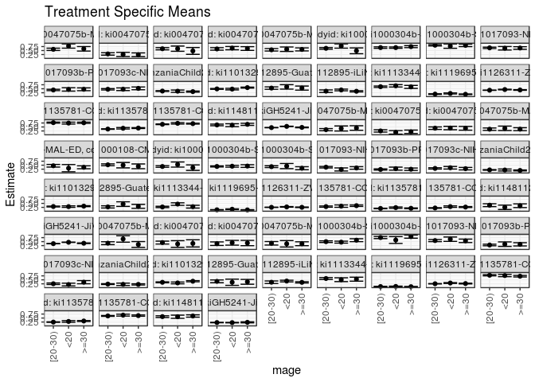

[figure not shown]

[figure not shown]

[figure not shown]

## Results Table

### Parameter: TSM

| agecat | studyid | country | intervention_level | baseline_level | estimate | ci_lower | ci_upper |
| --- | --- | --- | --- | --- | --- | --- | --- |
| 0-24 months | ki0047075b-MAL-ED | BANGLADESH | [20-30) | NA | 0.5769231 | 0.5050110 | 0.6488352 |
| 0-24 months | ki0047075b-MAL-ED | BANGLADESH | <20 | NA | 0.7837838 | 0.6508882 | 0.9166793 |
| 0-24 months | ki0047075b-MAL-ED | BANGLADESH | >=30 | NA | 0.6086957 | 0.4673939 | 0.7499974 |
| 0-24 months | ki0047075b-MAL-ED | BRAZIL | [20-30) | NA | 0.2877698 | 0.2123462 | 0.3631934 |
| 0-24 months | ki0047075b-MAL-ED | BRAZIL | <20 | NA | 0.2558140 | 0.1251214 | 0.3865065 |
| 0-24 months | ki0047075b-MAL-ED | BRAZIL | >=30 | NA | 0.2352941 | 0.1186267 | 0.3519616 |
| 0-24 months | ki0047075b-MAL-ED | INDIA | [20-30) | NA | 0.6134021 | 0.5447390 | 0.6820652 |
| 0-24 months | ki0047075b-MAL-ED | INDIA | <20 | NA | 0.6176471 | 0.4539711 | 0.7813230 |
| 0-24 months | ki0047075b-MAL-ED | INDIA | >=30 | NA | 0.4761905 | 0.2621532 | 0.6902277 |
| 0-24 months | ki0047075b-MAL-ED | PERU | [20-30) | NA | 0.6013072 | 0.5235953 | 0.6790191 |
| 0-24 months | ki0047075b-MAL-ED | PERU | <20 | NA | 0.6506024 | 0.5478612 | 0.7533436 |
| 0-24 months | ki0047075b-MAL-ED | PERU | >=30 | NA | 0.6268657 | 0.5108682 | 0.7428631 |
| 0-24 months | ki0047075b-MAL-ED | SOUTH AFRICA | [20-30) | NA | 0.5465839 | 0.4695636 | 0.6236041 |
| 0-24 months | ki0047075b-MAL-ED | SOUTH AFRICA | <20 | NA | 0.5833333 | 0.4436409 | 0.7230258 |
| 0-24 months | ki0047075b-MAL-ED | SOUTH AFRICA | >=30 | NA | 0.5714286 | 0.4766219 | 0.6662352 |
| 0-24 months | ki1000108-IRC | INDIA | [20-30) | NA | 0.6395349 | 0.5887350 | 0.6903348 |
| 0-24 months | ki1000108-IRC | INDIA | <20 | NA | 0.7837838 | 0.6509771 | 0.9165904 |
| 0-24 months | ki1000108-IRC | INDIA | >=30 | NA | 0.4827586 | 0.3006666 | 0.6648507 |
| 0-24 months | ki1000304b-SAS-CompFeed | INDIA | [20-30) | NA | 0.6846615 | 0.6367436 | 0.7325794 |
| 0-24 months | ki1000304b-SAS-CompFeed | INDIA | <20 | NA | 0.6839378 | 0.6407085 | 0.7271672 |
| 0-24 months | ki1000304b-SAS-CompFeed | INDIA | >=30 | NA | 0.7456647 | 0.6827952 | 0.8085342 |
| 0-24 months | ki1000304b-SAS-FoodSuppl | INDIA | [20-30) | NA | 0.8344828 | 0.7916575 | 0.8773080 |
| 0-24 months | ki1000304b-SAS-FoodSuppl | INDIA | <20 | NA | 0.7777778 | 0.6418092 | 0.9137463 |
| 0-24 months | ki1000304b-SAS-FoodSuppl | INDIA | >=30 | NA | 0.8260870 | 0.7485421 | 0.9036319 |
| 0-24 months | ki1017093-NIH-Birth | BANGLADESH | [20-30) | NA | 0.6682464 | 0.6232877 | 0.7132052 |
| 0-24 months | ki1017093-NIH-Birth | BANGLADESH | <20 | NA | 0.6438356 | 0.5338981 | 0.7537732 |
| 0-24 months | ki1017093-NIH-Birth | BANGLADESH | >=30 | NA | 0.6590909 | 0.5781627 | 0.7400191 |
| 0-24 months | ki1017093b-PROVIDE | BANGLADESH | [20-30) | NA | 0.4239351 | 0.3802815 | 0.4675887 |
| 0-24 months | ki1017093b-PROVIDE | BANGLADESH | <20 | NA | 0.4588235 | 0.3528149 | 0.5648322 |
| 0-24 months | ki1017093b-PROVIDE | BANGLADESH | >=30 | NA | 0.4672131 | 0.3786174 | 0.5558089 |

[output cut: 171 more lines]

### Parameter: E(Y)

| agecat | studyid | country | intervention_level | baseline_level | estimate | ci_lower | ci_upper |
| --- | --- | --- | --- | --- | --- | --- | --- |
| 0-24 months | ki0047075b-MAL-ED | BANGLADESH | NA | NA | 0.6113208 | 0.5525209 | 0.6701206 |
| 0-24 months | ki0047075b-MAL-ED | BRAZIL | NA | NA | 0.2703863 | 0.2132328 | 0.3275398 |
| 0-24 months | ki0047075b-MAL-ED | INDIA | NA | NA | 0.6024096 | 0.5415000 | 0.6633193 |
| 0-24 months | ki0047075b-MAL-ED | PERU | NA | NA | 0.6204620 | 0.5657315 | 0.6751926 |
| 0-24 months | ki0047075b-MAL-ED | SOUTH AFRICA | NA | NA | 0.5605096 | 0.5055248 | 0.6154943 |
| 0-24 months | ki1000108-IRC | INDIA | NA | NA | 0.6414634 | 0.5949863 | 0.6879405 |
| 0-24 months | ki1000304b-SAS-CompFeed | INDIA | NA | NA | 0.6914547 | 0.6510509 | 0.7318584 |
| 0-24 months | ki1000304b-SAS-FoodSuppl | INDIA | NA | NA | 0.8277512 | 0.7915095 | 0.8639929 |
| 0-24 months | ki1017093-NIH-Birth | BANGLADESH | NA | NA | 0.6634769 | 0.6264616 | 0.7004922 |
| 0-24 months | ki1017093b-PROVIDE | BANGLADESH | NA | NA | 0.4357143 | 0.3989556 | 0.4724730 |
| 0-24 months | ki1017093c-NIH-Crypto | BANGLADESH | NA | NA | 0.4775726 | 0.4419904 | 0.5131548 |
| 0-24 months | ki1066203-TanzaniaChild2 | TANZANIA, UNITED REPUBLIC OF | NA | NA | 0.3459596 | 0.3268289 | 0.3650903 |
| 0-24 months | ki1101329-Keneba | GAMBIA | NA | NA | 0.5183631 | 0.5000444 | 0.5366817 |
| 0-24 months | ki1112895-Guatemala BSC | GUATEMALA | NA | NA | 0.5551601 | 0.4969525 | 0.6133678 |
| 0-24 months | ki1112895-iLiNS-Zinc | BURKINA FASO | NA | NA | 0.3561989 | 0.3061990 | 0.4061987 |
| 0-24 months | ki1113344-GMS-Nepal | NEPAL | NA | NA | 0.6389685 | 0.6033115 | 0.6746254 |
| 0-24 months | ki1119695-PROBIT | BELARUS | NA | NA | 0.1674854 | 0.1488048 | 0.1861659 |
| 0-24 months | ki1126311-ZVITAMBO | ZIMBABWE | NA | NA | 0.4172011 | 0.4090427 | 0.4253595 |
| 0-24 months | ki1135781-COHORTS | GUATEMALA | NA | NA | 0.7639706 | 0.7413939 | 0.7865473 |
| 0-24 months | ki1135781-COHORTS | INDIA | NA | NA | 0.3877282 | 0.3746257 | 0.4008307 |
| 0-24 months | ki1135781-COHORTS | PHILIPPINES | NA | NA | 0.6863963 | 0.6699497 | 0.7028430 |
| 0-24 months | ki1148112-LCNI-5 | MALAWI | NA | NA | 0.6373134 | 0.6008819 | 0.6737450 |
| 0-24 months | kiGH5241-JiVitA-3 | BANGLADESH | NA | NA | 0.4952969 | 0.4874720 | 0.5031218 |
| 0-6 months | ki0047075b-MAL-ED | BANGLADESH | NA | NA | 0.3584906 | 0.3006428 | 0.4163383 |
| 0-6 months | ki0047075b-MAL-ED | BRAZIL | NA | NA | 0.2231760 | 0.1695976 | 0.2767543 |
| 0-6 months | ki0047075b-MAL-ED | PERU | NA | NA | 0.4257426 | 0.3699763 | 0.4815088 |
| 0-6 months | ki0047075b-MAL-ED | SOUTH AFRICA | NA | NA | 0.3694268 | 0.3159570 | 0.4228965 |
| 0-6 months | ki0047075b-MAL-ED | TANZANIA, UNITED REPUBLIC OF | NA | NA | 0.4160305 | 0.3562327 | 0.4758284 |
| 0-6 months | ki1000108-CMC-V-BCS-2002 | INDIA | NA | NA | 0.5108696 | 0.4597270 | 0.5620121 |
| 0-6 months | ki1000108-IRC | INDIA | NA | NA | 0.4243902 | 0.3764905 | 0.4722900 |
| 0-6 months | ki1000304b-SAS-CompFeed | INDIA | NA | NA | 0.4254902 | 0.3977202 | 0.4532601 |
| 0-6 months | ki1000304b-SAS-FoodSuppl | INDIA | NA | NA | 0.3894231 | 0.3425088 | 0.4363374 |
| 0-6 months | ki1017093-NIH-Birth | BANGLADESH | NA | NA | 0.3476874 | 0.3103810 | 0.3849938 |
| 0-6 months | ki1017093b-PROVIDE | BANGLADESH | NA | NA | 0.2400000 | 0.2083392 | 0.2716608 |
| 0-6 months | ki1017093c-NIH-Crypto | BANGLADESH | NA | NA | 0.3021108 | 0.2694011 | 0.3348205 |
| 0-6 months | ki1066203-TanzaniaChild2 | TANZANIA, UNITED REPUBLIC OF | NA | NA | 0.1944444 | 0.1785274 | 0.2103615 |
| 0-6 months | ki1101329-Keneba | GAMBIA | NA | NA | 0.3127302 | 0.2943427 | 0.3311178 |
| 0-6 months | ki1112895-Guatemala BSC | GUATEMALA | NA | NA | 0.3181818 | 0.2618904 | 0.3744732 |
| 0-6 months | ki1113344-GMS-Nepal | NEPAL | NA | NA | 0.3180516 | 0.2834770 | 0.3526261 |
| 0-6 months | ki1119695-PROBIT | BELARUS | NA | NA | 0.0995087 | 0.0864641 | 0.1125533 |
| 0-6 months | ki1126311-ZVITAMBO | ZIMBABWE | NA | NA | 0.2587572 | 0.2515068 | 0.2660076 |
| 0-6 months | ki1135781-COHORTS | GUATEMALA | NA | NA | 0.3253896 | 0.2975756 | 0.3532035 |
| 0-6 months | ki1135781-COHORTS | INDIA | NA | NA | 0.1902629 | 0.1795262 | 0.2009996 |
| 0-6 months | ki1135781-COHORTS | PHILIPPINES | NA | NA | 0.2390451 | 0.2239262 | 0.2541640 |
| 0-6 months | ki1148112-LCNI-5 | MALAWI | NA | NA | 0.3545455 | 0.2911884 | 0.4179025 |
| 0-6 months | kiGH5241-JiVitA-3 | BANGLADESH | NA | NA | 0.4129650 | 0.4055288 | 0.4204012 |
| 6-24 months | ki0047075b-MAL-ED | BANGLADESH | NA | NA | 0.4240506 | 0.3467471 | 0.5013542 |
| 6-24 months | ki0047075b-MAL-ED | INDIA | NA | NA | 0.4220779 | 0.3438191 | 0.5003367 |
| 6-24 months | ki0047075b-MAL-ED | PERU | NA | NA | 0.3959732 | 0.3171819 | 0.4747644 |
| 6-24 months | ki0047075b-MAL-ED | SOUTH AFRICA | NA | NA | 0.3797468 | 0.3038314 | 0.4556622 |
| 6-24 months | ki1000304b-SAS-CompFeed | INDIA | NA | NA | 0.5030750 | 0.4588491 | 0.5473009 |
| 6-24 months | ki1000304b-SAS-FoodSuppl | INDIA | NA | NA | 0.7572016 | 0.7031798 | 0.8112234 |
| 6-24 months | ki1017093-NIH-Birth | BANGLADESH | NA | NA | 0.5739130 | 0.5216565 | 0.6261696 |
| 6-24 months | ki1017093b-PROVIDE | BANGLADESH | NA | NA | 0.3004386 | 0.2583143 | 0.3425629 |
| 6-24 months | ki1017093c-NIH-Crypto | BANGLADESH | NA | NA | 0.2628458 | 0.2244546 | 0.3012371 |
| 6-24 months | ki1066203-TanzaniaChild2 | TANZANIA, UNITED REPUBLIC OF | NA | NA | 0.2262728 | 0.2057063 | 0.2468392 |
| 6-24 months | ki1101329-Keneba | GAMBIA | NA | NA | 0.3640974 | 0.3428547 | 0.3853400 |
| 6-24 months | ki1112895-Guatemala BSC | GUATEMALA | NA | NA | 0.3913043 | 0.3205945 | 0.4620142 |
| 6-24 months | ki1112895-iLiNS-Zinc | BURKINA FASO | NA | NA | 0.3561989 | 0.3061990 | 0.4061987 |
| 6-24 months | ki1113344-GMS-Nepal | NEPAL | NA | NA | 0.5642317 | 0.5153938 | 0.6130696 |
| 6-24 months | ki1119695-PROBIT | BELARUS | NA | NA | 0.0768510 | 0.0628857 | 0.0908164 |
| 6-24 months | ki1126311-ZVITAMBO | ZIMBABWE | NA | NA | 0.2628598 | 0.2534882 | 0.2722315 |
| 6-24 months | ki1135781-COHORTS | GUATEMALA | NA | NA | 0.7642458 | 0.7364214 | 0.7920702 |
| 6-24 months | ki1135781-COHORTS | INDIA | NA | NA | 0.2666174 | 0.2530174 | 0.2802175 |
| 6-24 months | ki1135781-COHORTS | PHILIPPINES | NA | NA | 0.6449788 | 0.6246093 | 0.6653483 |
| 6-24 months | ki1148112-LCNI-5 | MALAWI | NA | NA | 0.6006885 | 0.5608305 | 0.6405464 |
| 6-24 months | kiGH5241-JiVitA-3 | BANGLADESH | NA | NA | 0.2162471 | 0.2068695 | 0.2256248 |

### Parameter: RR

| agecat | studyid | country | intervention_level | baseline_level | estimate | ci_lower | ci_upper |
| --- | --- | --- | --- | --- | --- | --- | --- |
| 0-24 months | ki0047075b-MAL-ED | BANGLADESH | [20-30) | [20-30) | 1.0000000 | 1.0000000 | 1.0000000 |
| 0-24 months | ki0047075b-MAL-ED | BANGLADESH | <20 | [20-30) | 1.3585586 | 1.1007380 | 1.6767671 |
| 0-24 months | ki0047075b-MAL-ED | BANGLADESH | >=30 | [20-30) | 1.0550725 | 0.8106836 | 1.3731349 |
| 0-24 months | ki0047075b-MAL-ED | BRAZIL | [20-30) | [20-30) | 1.0000000 | 1.0000000 | 1.0000000 |
| 0-24 months | ki0047075b-MAL-ED | BRAZIL | <20 | [20-30) | 0.8889535 | 0.5006202 | 1.5785186 |
| 0-24 months | ki0047075b-MAL-ED | BRAZIL | >=30 | [20-30) | 0.8176471 | 0.4666522 | 1.4326446 |
| 0-24 months | ki0047075b-MAL-ED | INDIA | [20-30) | [20-30) | 1.0000000 | 1.0000000 | 1.0000000 |
| 0-24 months | ki0047075b-MAL-ED | INDIA | <20 | [20-30) | 1.0069204 | 0.7551985 | 1.3425459 |
| 0-24 months | ki0047075b-MAL-ED | INDIA | >=30 | [20-30) | 0.7763105 | 0.4885030 | 1.2336835 |
| 0-24 months | ki0047075b-MAL-ED | PERU | [20-30) | [20-30) | 1.0000000 | 1.0000000 | 1.0000000 |
| 0-24 months | ki0047075b-MAL-ED | PERU | <20 | [20-30) | 1.0819801 | 0.8822614 | 1.3269093 |
| 0-24 months | ki0047075b-MAL-ED | PERU | >=30 | [20-30) | 1.0425049 | 0.8318687 | 1.3064759 |
| 0-24 months | ki0047075b-MAL-ED | SOUTH AFRICA | [20-30) | [20-30) | 1.0000000 | 1.0000000 | 1.0000000 |
| 0-24 months | ki0047075b-MAL-ED | SOUTH AFRICA | <20 | [20-30) | 1.0672348 | 0.8083308 | 1.4090645 |
| 0-24 months | ki0047075b-MAL-ED | SOUTH AFRICA | >=30 | [20-30) | 1.0454545 | 0.8409490 | 1.2996926 |
| 0-24 months | ki1000108-IRC | INDIA | [20-30) | [20-30) | 1.0000000 | 1.0000000 | 1.0000000 |
| 0-24 months | ki1000108-IRC | INDIA | <20 | [20-30) | 1.2255528 | 1.0163873 | 1.4777631 |
| 0-24 months | ki1000108-IRC | INDIA | >=30 | [20-30) | 0.7548589 | 0.5134061 | 1.1098662 |
| 0-24 months | ki1000304b-SAS-CompFeed | INDIA | [20-30) | [20-30) | 1.0000000 | 1.0000000 | 1.0000000 |
| 0-24 months | ki1000304b-SAS-CompFeed | INDIA | <20 | [20-30) | 0.9989430 | 0.9152635 | 1.0902730 |
| 0-24 months | ki1000304b-SAS-CompFeed | INDIA | >=30 | [20-30) | 1.0890998 | 1.0001171 | 1.1859995 |
| 0-24 months | ki1000304b-SAS-FoodSuppl | INDIA | [20-30) | [20-30) | 1.0000000 | 1.0000000 | 1.0000000 |
| 0-24 months | ki1000304b-SAS-FoodSuppl | INDIA | <20 | [20-30) | 0.9320478 | 0.7768057 | 1.1183144 |
| 0-24 months | ki1000304b-SAS-FoodSuppl | INDIA | >=30 | [20-30) | 0.9899389 | 0.8895009 | 1.1017178 |
| 0-24 months | ki1017093-NIH-Birth | BANGLADESH | [20-30) | [20-30) | 1.0000000 | 1.0000000 | 1.0000000 |
| 0-24 months | ki1017093-NIH-Birth | BANGLADESH | <20 | [20-30) | 0.9634703 | 0.8019220 | 1.1575627 |
| 0-24 months | ki1017093-NIH-Birth | BANGLADESH | >=30 | [20-30) | 0.9862992 | 0.8574375 | 1.1345271 |
| 0-24 months | ki1017093b-PROVIDE | BANGLADESH | [20-30) | [20-30) | 1.0000000 | 1.0000000 | 1.0000000 |
| 0-24 months | ki1017093b-PROVIDE | BANGLADESH | <20 | [20-30) | 1.0822967 | 0.8404086 | 1.3938054 |
| 0-24 months | ki1017093b-PROVIDE | BANGLADESH | >=30 | [20-30) | 1.1020864 | 0.8881846 | 1.3675023 |

[output cut: 171 more lines]

### Parameter: PAR

| agecat | studyid | country | intervention_level | baseline_level | estimate | ci_lower | ci_upper |
| --- | --- | --- | --- | --- | --- | --- | --- |
| 0-24 months | ki0047075b-MAL-ED | BANGLADESH | [20-30) | NA | 0.0343977 | -0.0046598 | 0.0734552 |
| 0-24 months | ki0047075b-MAL-ED | BRAZIL | [20-30) | NA | -0.0173835 | -0.0639436 | 0.0291766 |
| 0-24 months | ki0047075b-MAL-ED | INDIA | [20-30) | NA | -0.0109924 | -0.0438273 | 0.0218424 |
| 0-24 months | ki0047075b-MAL-ED | PERU | [20-30) | NA | 0.0191549 | -0.0350267 | 0.0733364 |
| 0-24 months | ki0047075b-MAL-ED | SOUTH AFRICA | [20-30) | NA | 0.0139257 | -0.0396671 | 0.0675185 |
| 0-24 months | ki1000108-IRC | INDIA | [20-30) | NA | 0.0019285 | -0.0183280 | 0.0221851 |
| 0-24 months | ki1000304b-SAS-CompFeed | INDIA | [20-30) | NA | 0.0067931 | -0.0056756 | 0.0192618 |
| 0-24 months | ki1000304b-SAS-FoodSuppl | INDIA | [20-30) | NA | -0.0067316 | -0.0312810 | 0.0178179 |
| 0-24 months | ki1017093-NIH-Birth | BANGLADESH | [20-30) | NA | -0.0047696 | -0.0306651 | 0.0211260 |
| 0-24 months | ki1017093b-PROVIDE | BANGLADESH | [20-30) | NA | 0.0117792 | -0.0121501 | 0.0357085 |
| 0-24 months | ki1017093c-NIH-Crypto | BANGLADESH | [20-30) | NA | 0.0099612 | -0.0160754 | 0.0359979 |
| 0-24 months | ki1066203-TanzaniaChild2 | TANZANIA, UNITED REPUBLIC OF | [20-30) | NA | -0.0098647 | -0.0234741 | 0.0037446 |
| 0-24 months | ki1101329-Keneba | GAMBIA | [20-30) | NA | 0.0277576 | 0.0095349 | 0.0459803 |
| 0-24 months | ki1112895-Guatemala BSC | GUATEMALA | [20-30) | NA | 0.0123030 | -0.0329266 | 0.0575326 |
| 0-24 months | ki1112895-iLiNS-Zinc | BURKINA FASO | [20-30) | NA | 0.0073750 | -0.0276097 | 0.0423597 |
| 0-24 months | ki1113344-GMS-Nepal | NEPAL | [20-30) | NA | 0.0103331 | -0.0162609 | 0.0369272 |
| 0-24 months | ki1119695-PROBIT | BELARUS | [20-30) | NA | 0.0018493 | -0.0029363 | 0.0066349 |
| 0-24 months | ki1126311-ZVITAMBO | ZIMBABWE | [20-30) | NA | 0.0095267 | 0.0038093 | 0.0152441 |
| 0-24 months | ki1135781-COHORTS | GUATEMALA | [20-30) | NA | -0.0075877 | -0.0307900 | 0.0156147 |
| 0-24 months | ki1135781-COHORTS | INDIA | [20-30) | NA | 0.0190441 | 0.0099167 | 0.0281716 |
| 0-24 months | ki1135781-COHORTS | PHILIPPINES | [20-30) | NA | 0.0186350 | 0.0052354 | 0.0320345 |
| 0-24 months | ki1148112-LCNI-5 | MALAWI | [20-30) | NA | 0.0081926 | -0.0251807 | 0.0415658 |
| 0-24 months | kiGH5241-JiVitA-3 | BANGLADESH | [20-30) | NA | 0.0357268 | 0.0290547 | 0.0423989 |
| 0-6 months | ki0047075b-MAL-ED | BANGLADESH | [20-30) | NA | 0.0288202 | -0.0111450 | 0.0687855 |
| 0-6 months | ki0047075b-MAL-ED | BRAZIL | [20-30) | NA | -0.0286226 | -0.0717589 | 0.0145137 |
| 0-6 months | ki0047075b-MAL-ED | PERU | [20-30) | NA | 0.0009060 | -0.0543112 | 0.0561231 |
| 0-6 months | ki0047075b-MAL-ED | SOUTH AFRICA | [20-30) | NA | 0.0091783 | -0.0429606 | 0.0613172 |
| 0-6 months | ki0047075b-MAL-ED | TANZANIA, UNITED REPUBLIC OF | [20-30) | NA | -0.0482552 | -0.1039787 | 0.0074683 |
| 0-6 months | ki1000108-CMC-V-BCS-2002 | INDIA | [20-30) | NA | -0.0131030 | -0.0392621 | 0.0130560 |
| 0-6 months | ki1000108-IRC | INDIA | [20-30) | NA | 0.0057856 | -0.0153591 | 0.0269303 |
| 0-6 months | ki1000304b-SAS-CompFeed | INDIA | [20-30) | NA | 0.0045280 | -0.0111485 | 0.0202045 |
| 0-6 months | ki1000304b-SAS-FoodSuppl | INDIA | [20-30) | NA | -0.0188814 | -0.0496610 | 0.0118982 |
| 0-6 months | ki1017093-NIH-Birth | BANGLADESH | [20-30) | NA | -0.0267202 | -0.0522675 | -0.0011729 |
| 0-6 months | ki1017093b-PROVIDE | BANGLADESH | [20-30) | NA | 0.0087627 | -0.0121098 | 0.0296352 |
| 0-6 months | ki1017093c-NIH-Crypto | BANGLADESH | [20-30) | NA | 0.0045400 | -0.0194616 | 0.0285415 |
| 0-6 months | ki1066203-TanzaniaChild2 | TANZANIA, UNITED REPUBLIC OF | [20-30) | NA | -0.0098840 | -0.0210703 | 0.0013023 |
| 0-6 months | ki1101329-Keneba | GAMBIA | [20-30) | NA | 0.0072695 | -0.0118693 | 0.0264083 |
| 0-6 months | ki1112895-Guatemala BSC | GUATEMALA | [20-30) | NA | 0.0376940 | -0.0072323 | 0.0826204 |
| 0-6 months | ki1113344-GMS-Nepal | NEPAL | [20-30) | NA | 0.0406467 | 0.0139825 | 0.0673108 |
| 0-6 months | ki1119695-PROBIT | BELARUS | [20-30) | NA | 0.0027079 | -0.0007959 | 0.0062117 |
| 0-6 months | ki1126311-ZVITAMBO | ZIMBABWE | [20-30) | NA | 0.0041944 | -0.0008955 | 0.0092843 |
| 0-6 months | ki1135781-COHORTS | GUATEMALA | [20-30) | NA | 0.0259545 | -0.0025761 | 0.0544851 |
| 0-6 months | ki1135781-COHORTS | INDIA | [20-30) | NA | 0.0059390 | -0.0015534 | 0.0134315 |
| 0-6 months | ki1135781-COHORTS | PHILIPPINES | [20-30) | NA | 0.0272225 | 0.0145678 | 0.0398772 |
| 0-6 months | ki1148112-LCNI-5 | MALAWI | [20-30) | NA | -0.0333856 | -0.0932459 | 0.0264748 |
| 0-6 months | kiGH5241-JiVitA-3 | BANGLADESH | [20-30) | NA | 0.0401933 | 0.0335007 | 0.0468859 |
| 6-24 months | ki0047075b-MAL-ED | BANGLADESH | [20-30) | NA | 0.0222649 | -0.0278377 | 0.0723675 |
| 6-24 months | ki0047075b-MAL-ED | INDIA | [20-30) | NA | -0.0175773 | -0.0619084 | 0.0267539 |
| 6-24 months | ki0047075b-MAL-ED | PERU | [20-30) | NA | 0.0261101 | -0.0542433 | 0.1064636 |
| 6-24 months | ki0047075b-MAL-ED | SOUTH AFRICA | [20-30) | NA | -0.0149900 | -0.0938865 | 0.0639065 |
| 6-24 months | ki1000304b-SAS-CompFeed | INDIA | [20-30) | NA | 0.0062905 | -0.0117154 | 0.0242963 |
| 6-24 months | ki1000304b-SAS-FoodSuppl | INDIA | [20-30) | NA | 0.0011041 | -0.0363276 | 0.0385358 |
| 6-24 months | ki1017093-NIH-Birth | BANGLADESH | [20-30) | NA | 0.0077030 | -0.0318697 | 0.0472757 |
| 6-24 months | ki1017093b-PROVIDE | BANGLADESH | [20-30) | NA | 0.0125598 | -0.0139828 | 0.0391024 |
| 6-24 months | ki1017093c-NIH-Crypto | BANGLADESH | [20-30) | NA | 0.0083004 | -0.0199891 | 0.0365899 |
| 6-24 months | ki1066203-TanzaniaChild2 | TANZANIA, UNITED REPUBLIC OF | [20-30) | NA | -0.0068320 | -0.0220700 | 0.0084060 |
| 6-24 months | ki1101329-Keneba | GAMBIA | [20-30) | NA | 0.0184798 | -0.0023875 | 0.0393472 |
| 6-24 months | ki1112895-Guatemala BSC | GUATEMALA | [20-30) | NA | -0.0136543 | -0.0644013 | 0.0370926 |
| 6-24 months | ki1112895-iLiNS-Zinc | BURKINA FASO | [20-30) | NA | 0.0073750 | -0.0276097 | 0.0423597 |
| 6-24 months | ki1113344-GMS-Nepal | NEPAL | [20-30) | NA | -0.0194114 | -0.0533161 | 0.0144934 |
| 6-24 months | ki1119695-PROBIT | BELARUS | [20-30) | NA | -0.0008523 | -0.0042181 | 0.0025136 |
| 6-24 months | ki1126311-ZVITAMBO | ZIMBABWE | [20-30) | NA | 0.0092671 | 0.0026579 | 0.0158763 |
| 6-24 months | ki1135781-COHORTS | GUATEMALA | [20-30) | NA | -0.0245182 | -0.0524868 | 0.0034503 |
| 6-24 months | ki1135781-COHORTS | INDIA | [20-30) | NA | 0.0193211 | 0.0098007 | 0.0288416 |
| 6-24 months | ki1135781-COHORTS | PHILIPPINES | [20-30) | NA | 0.0105538 | -0.0053609 | 0.0264685 |
| 6-24 months | ki1148112-LCNI-5 | MALAWI | [20-30) | NA | 0.0109449 | -0.0260389 | 0.0479287 |
| 6-24 months | kiGH5241-JiVitA-3 | BANGLADESH | [20-30) | NA | -0.0013400 | -0.0101264 | 0.0074463 |

### Parameter: PAF

| agecat | studyid | country | intervention_level | baseline_level | estimate | ci_lower | ci_upper |
| --- | --- | --- | --- | --- | --- | --- | --- |
| 0-24 months | ki0047075b-MAL-ED | BANGLADESH | [20-30) | NA | 0.0562678 | -0.0103161 | 0.1184636 |
| 0-24 months | ki0047075b-MAL-ED | BRAZIL | [20-30) | NA | -0.0642914 | -0.2510700 | 0.0946020 |
| 0-24 months | ki0047075b-MAL-ED | INDIA | [20-30) | NA | -0.0182474 | -0.0743072 | 0.0348870 |
| 0-24 months | ki0047075b-MAL-ED | PERU | [20-30) | NA | 0.0308719 | -0.0606084 | 0.1144618 |
| 0-24 months | ki0047075b-MAL-ED | SOUTH AFRICA | [20-30) | NA | 0.0248447 | -0.0756651 | 0.1159630 |
| 0-24 months | ki1000108-IRC | INDIA | [20-30) | NA | 0.0030065 | -0.0290797 | 0.0340921 |
| 0-24 months | ki1000304b-SAS-CompFeed | INDIA | [20-30) | NA | 0.0098244 | -0.0086751 | 0.0279846 |
| 0-24 months | ki1000304b-SAS-FoodSuppl | INDIA | [20-30) | NA | -0.0081324 | -0.0382500 | 0.0211116 |
| 0-24 months | ki1017093-NIH-Birth | BANGLADESH | [20-30) | NA | -0.0071888 | -0.0469913 | 0.0311006 |
| 0-24 months | ki1017093b-PROVIDE | BANGLADESH | [20-30) | NA | 0.0270342 | -0.0294902 | 0.0804551 |
| 0-24 months | ki1017093c-NIH-Crypto | BANGLADESH | [20-30) | NA | 0.0208580 | -0.0352256 | 0.0739033 |
| 0-24 months | ki1066203-TanzaniaChild2 | TANZANIA, UNITED REPUBLIC OF | [20-30) | NA | -0.0285141 | -0.0686170 | 0.0100838 |
| 0-24 months | ki1101329-Keneba | GAMBIA | [20-30) | NA | 0.0535486 | 0.0176785 | 0.0881090 |
| 0-24 months | ki1112895-Guatemala BSC | GUATEMALA | [20-30) | NA | 0.0221612 | -0.0628522 | 0.1003747 |
| 0-24 months | ki1112895-iLiNS-Zinc | BURKINA FASO | [20-30) | NA | 0.0207047 | -0.0850608 | 0.1161608 |
| 0-24 months | ki1113344-GMS-Nepal | NEPAL | [20-30) | NA | 0.0161716 | -0.0263670 | 0.0569471 |
| 0-24 months | ki1119695-PROBIT | BELARUS | [20-30) | NA | 0.0110414 | -0.0178551 | 0.0391175 |
| 0-24 months | ki1126311-ZVITAMBO | ZIMBABWE | [20-30) | NA | 0.0228348 | 0.0090312 | 0.0364461 |
| 0-24 months | ki1135781-COHORTS | GUATEMALA | [20-30) | NA | -0.0099319 | -0.0407719 | 0.0199943 |
| 0-24 months | ki1135781-COHORTS | INDIA | [20-30) | NA | 0.0491173 | 0.0252704 | 0.0723807 |
| 0-24 months | ki1135781-COHORTS | PHILIPPINES | [20-30) | NA | 0.0271490 | 0.0073942 | 0.0465106 |
| 0-24 months | ki1148112-LCNI-5 | MALAWI | [20-30) | NA | 0.0128548 | -0.0409379 | 0.0638677 |
| 0-24 months | kiGH5241-JiVitA-3 | BANGLADESH | [20-30) | NA | 0.0721320 | 0.0585003 | 0.0855664 |
| 0-6 months | ki0047075b-MAL-ED | BANGLADESH | [20-30) | NA | 0.0803933 | -0.0381514 | 0.1854016 |
| 0-6 months | ki0047075b-MAL-ED | BRAZIL | [20-30) | NA | -0.1282512 | -0.3380526 | 0.0486541 |
| 0-6 months | ki0047075b-MAL-ED | PERU | [20-30) | NA | 0.0021280 | -0.1363740 | 0.1237493 |
| 0-6 months | ki0047075b-MAL-ED | SOUTH AFRICA | [20-30) | NA | 0.0248447 | -0.1270216 | 0.1562471 |
| 0-6 months | ki0047075b-MAL-ED | TANZANIA, UNITED REPUBLIC OF | [20-30) | NA | -0.1159895 | -0.2589886 | 0.0107674 |
| 0-6 months | ki1000108-CMC-V-BCS-2002 | INDIA | [20-30) | NA | -0.0256485 | -0.0782305 | 0.0243692 |
| 0-6 months | ki1000108-IRC | INDIA | [20-30) | NA | 0.0136327 | -0.0374821 | 0.0622292 |
| 0-6 months | ki1000304b-SAS-CompFeed | INDIA | [20-30) | NA | 0.0106418 | -0.0269944 | 0.0468988 |
| 0-6 months | ki1000304b-SAS-FoodSuppl | INDIA | [20-30) | NA | -0.0484856 | -0.1306585 | 0.0277151 |
| 0-6 months | ki1017093-NIH-Birth | BANGLADESH | [20-30) | NA | -0.0768512 | -0.1529670 | -0.0057603 |
| 0-6 months | ki1017093b-PROVIDE | BANGLADESH | [20-30) | NA | 0.0365112 | -0.0544463 | 0.1196225 |
| 0-6 months | ki1017093c-NIH-Crypto | BANGLADESH | [20-30) | NA | 0.0150275 | -0.0677080 | 0.0913519 |
| 0-6 months | ki1066203-TanzaniaChild2 | TANZANIA, UNITED REPUBLIC OF | [20-30) | NA | -0.0508320 | -0.1098873 | 0.0050810 |
| 0-6 months | ki1101329-Keneba | GAMBIA | [20-30) | NA | 0.0232453 | -0.0399098 | 0.0825649 |
| 0-6 months | ki1112895-Guatemala BSC | GUATEMALA | [20-30) | NA | 0.1184669 | -0.0343430 | 0.2487012 |
| 0-6 months | ki1113344-GMS-Nepal | NEPAL | [20-30) | NA | 0.1277989 | 0.0400380 | 0.2075367 |
| 0-6 months | ki1119695-PROBIT | BELARUS | [20-30) | NA | 0.0272125 | -0.0076988 | 0.0609143 |
| 0-6 months | ki1126311-ZVITAMBO | ZIMBABWE | [20-30) | NA | 0.0162098 | -0.0036571 | 0.0356835 |
| 0-6 months | ki1135781-COHORTS | GUATEMALA | [20-30) | NA | 0.0797645 | -0.0121972 | 0.1633711 |
| 0-6 months | ki1135781-COHORTS | INDIA | [20-30) | NA | 0.0312149 | -0.0089535 | 0.0697842 |
| 0-6 months | ki1135781-COHORTS | PHILIPPINES | [20-30) | NA | 0.1138800 | 0.0595592 | 0.1650632 |
| 0-6 months | ki1148112-LCNI-5 | MALAWI | [20-30) | NA | -0.0941645 | -0.2769219 | 0.0624361 |
| 0-6 months | kiGH5241-JiVitA-3 | BANGLADESH | [20-30) | NA | 0.0973285 | 0.0809329 | 0.1134317 |
| 6-24 months | ki0047075b-MAL-ED | BANGLADESH | [20-30) | NA | 0.0525053 | -0.0735034 | 0.1637230 |
| 6-24 months | ki0047075b-MAL-ED | INDIA | [20-30) | NA | -0.0416446 | -0.1523167 | 0.0583983 |
| 6-24 months | ki0047075b-MAL-ED | PERU | [20-30) | NA | 0.0659392 | -0.1608356 | 0.2484124 |
| 6-24 months | ki0047075b-MAL-ED | SOUTH AFRICA | [20-30) | NA | -0.0394737 | -0.2695024 | 0.1488748 |
| 6-24 months | ki1000304b-SAS-CompFeed | INDIA | [20-30) | NA | 0.0125040 | -0.0241665 | 0.0478615 |
| 6-24 months | ki1000304b-SAS-FoodSuppl | INDIA | [20-30) | NA | 0.0014581 | -0.0492208 | 0.0496892 |
| 6-24 months | ki1017093-NIH-Birth | BANGLADESH | [20-30) | NA | 0.0134219 | -0.0580165 | 0.0800367 |
| 6-24 months | ki1017093b-PROVIDE | BANGLADESH | [20-30) | NA | 0.0418049 | -0.0507043 | 0.1261691 |
| 6-24 months | ki1017093c-NIH-Crypto | BANGLADESH | [20-30) | NA | 0.0315789 | -0.0822230 | 0.1334140 |
| 6-24 months | ki1066203-TanzaniaChild2 | TANZANIA, UNITED REPUBLIC OF | [20-30) | NA | -0.0301937 | -0.0997635 | 0.0349752 |
| 6-24 months | ki1101329-Keneba | GAMBIA | [20-30) | NA | 0.0507552 | -0.0083299 | 0.1063781 |
| 6-24 months | ki1112895-Guatemala BSC | GUATEMALA | [20-30) | NA | -0.0348944 | -0.1731146 | 0.0870403 |
| 6-24 months | ki1112895-iLiNS-Zinc | BURKINA FASO | [20-30) | NA | 0.0207047 | -0.0850608 | 0.1161608 |
| 6-24 months | ki1113344-GMS-Nepal | NEPAL | [20-30) | NA | -0.0344032 | -0.0964041 | 0.0240916 |
| 6-24 months | ki1119695-PROBIT | BELARUS | [20-30) | NA | -0.0110901 | -0.0550535 | 0.0310414 |
| 6-24 months | ki1126311-ZVITAMBO | ZIMBABWE | [20-30) | NA | 0.0352550 | 0.0097912 | 0.0600640 |
| 6-24 months | ki1135781-COHORTS | GUATEMALA | [20-30) | NA | -0.0320816 | -0.0694442 | 0.0039757 |
| 6-24 months | ki1135781-COHORTS | INDIA | [20-30) | NA | 0.0724675 | 0.0361278 | 0.1074372 |
| 6-24 months | ki1135781-COHORTS | PHILIPPINES | [20-30) | NA | 0.0163630 | -0.0086381 | 0.0407445 |
| 6-24 months | ki1148112-LCNI-5 | MALAWI | [20-30) | NA | 0.0182206 | -0.0453447 | 0.0779206 |
| 6-24 months | kiGH5241-JiVitA-3 | BANGLADESH | [20-30) | NA | -0.0061967 | -0.0476484 | 0.0336150 |